# EX3 (2)

[figure not shown]

```python
plt.figure(figsize=(20,8))
plt.title('''
We can see that if you are young between the ages of 25-35 the chances of surviving are higher than the rest of the ages
'''
)
sns.countplot('Age',data=train_cpy,hue='Survived')
plt.show()
```

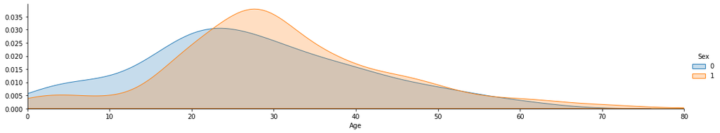

```python
'''
The range of Age separate by gender
Here we can see that men and women are in the same age range,
'''
as_fig = sns.FacetGrid(train,hue='Sex',aspect=5)

as_fig.map(sns.kdeplot,'Age',shade=True)

oldest = train['Age'].max()

as_fig.set(xlim=(0,oldest))

as_fig.add_legend()
```

```
The range of Age separate by Pclass:
Here we can see that most of the people who chose the third class are at younger ages than the other classes
```

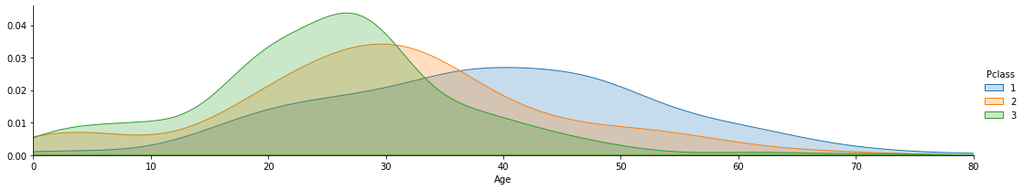

```python
print("""
The range of Age separate by Pclass:
Here we can see that most of the people who chose the third class are at younger ages than the other classes
""")
as_fig = sns.FacetGrid(train,hue='Pclass',aspect=5)

as_fig.map(sns.kdeplot,'Age',shade=True)

oldest = train['Age'].max()

as_fig.set(xlim=(0,oldest))

as_fig.add_legend()
```

```
Most of the passengers boarded at station S.
```

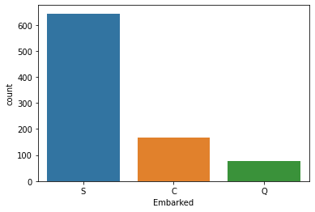

```python
print('''
Most of the passengers boarded at station S.
''')
sns.countplot('Embarked',data=train_cpy)
```

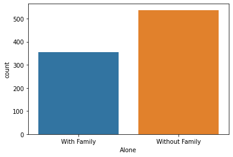

```python
'''
Alone colunm can help us for better results!!
But I decided not to use this column

'''



## Let's check who are with family and who are alone
## This can be found by adding Parch and Sibsp columns
training_set_for_viz = train.copy()
training_set_for_viz['Alone'] = training_set_for_viz.Parch + training_set_for_viz.SibSp

## if Alone value is >0 then they are with family else they are Alone
training_set_for_viz['Alone'].loc[training_set_for_viz['Alone']>0] = 'With Family'
training_set_for_viz['Alone'].loc[training_set_for_viz['Alone'] == 0] = 'Without Family'
sns.countplot('Alone',data=training_set_for_viz)
```

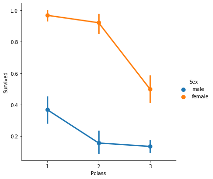

```python
# we can see - if i will be a female with Pclass , i had a lot of chance to survive
sns.factorplot('Pclass','Survived',data=train_cpy,hue='Sex')
plt.show()
```

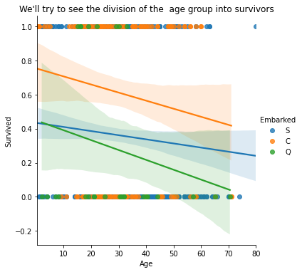

```python
sns.lmplot('Age','Survived',data=train_cpy,hue='Embarked')
plt.title("We'll try to see the division of the "" age group into survivors")
```

# fill cabin

### Find the best model for filling in the missing data - CABIN!

```python
classifiers = [
    KNeighborsClassifier(6),
    SVC(kernel='poly', gamma='auto',C=5 ,random_state=1),
    DecisionTreeClassifier(random_state=1),
    RandomForestClassifier(random_state=1),
	  AdaBoostClassifier(random_state=1),
    GradientBoostingClassifier(random_state=1,n_estimators=1000),
    GaussianNB(),
    LinearDiscriminantAnalysis(),
    LogisticRegression()]
```

```python
cabin_full = train[train.Cabin.isna() == False]
# best_features = cabin_full.corrwith(pd.Series(LabelEncoder().fit_transform(y)))[abs(cabin_full.corrwith(pd.Series(LabelEncoder().fit_transform(y_Survived)))).sort_values(ascending=False)>0.1].index
cabin_null = train[train.Cabin.isna()].drop(['Cabin'],axis=1)
cabin_full = pd.concat([cabin_full,test[test.Cabin.isna() == False][cabin_full.columns]])
y = cabin_full.Cabin
cabin_full.drop(['Cabin','PassengerId'],axis=1,inplace=True)
X = cabin_full
sd = StandardScaler()
X = pd.DataFrame(sd.fit_transform(X),columns=cabin_full.columns)
df_cabin_statics = pd.DataFrame()

X_train, X_test, y_train, y_test = train_test_split(X, y, test_size=0.1, random_state=1)

for model in classifiers:
  model = model.fit(X_train, y_train)
  preds = model.predict(X_test)
  ACC_train = accuracy_score(model.predict(X_train),y_train)
  ACC_test = accuracy_score(preds,y_test)
  df_cabin_statics = df_cabin_statics.append({'Classifier':str(model).split('(')[0],'Accuracy train':ACC_train,'Accuracy test':ACC_test},ignore_index=True)
```

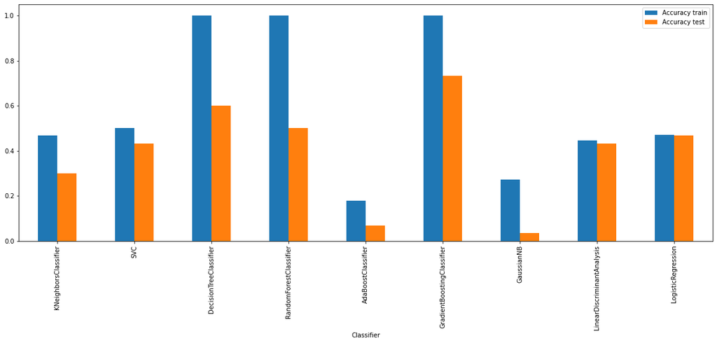

|  | Accuracy test | Accuracy train | Classifier |
| --- | --- | --- | --- |
| 0 | 0.300000 | 0.467925 | KNeighborsClassifier |
| 1 | 0.433333 | 0.501887 | SVC |
| 2 | 0.600000 | 1.000000 | DecisionTreeClassifier |
| 3 | 0.500000 | 1.000000 | RandomForestClassifier |
| 4 | 0.066667 | 0.177358 | AdaBoostClassifier |
| 5 | 0.733333 | 1.000000 | GradientBoostingClassifier |
| 6 | 0.033333 | 0.271698 | GaussianNB |
| 7 | 0.433333 | 0.445283 | LinearDiscriminantAnalysis |
| 8 | 0.466667 | 0.471698 | LogisticRegression |

```python
df_cabin_statics.plot(x='Classifier',y=['Accuracy train','Accuracy test'],kind='bar',figsize=(20,7))
plt.show()
df_cabin_statics
```

```python
model = SVC(kernel='poly', gamma='auto' ,random_state=1).fit(X_train, y_train)

cabin_null = train[train.Cabin.isna()].drop(['Cabin'],axis=1)
cabin_null = pd.DataFrame(sd.transform(cabin_null[X_train.columns]),columns=X_train.columns)
results = model.predict(cabin_null[X_train.columns])

cabin_null = test[test.Cabin.isna()].drop(['Cabin','PassengerId'],axis=1)
cabin_null = pd.DataFrame(sd.transform(cabin_null),columns=cabin_null.columns)
test_res = model.predict(cabin_null)
```

```python
train.loc[train.Cabin.isna() == True,'Cabin'] = results
test.loc[test.Cabin.isna() == True,'Cabin'] = test_res
```

```python
train.isna().sum()[train.isna().sum() != 0]
```

```
Series([], dtype: int64)
```

## No more missing data!

Let's get to work

```python
# abs(cabin_full.corrwith(pd.Series(LabelEncoder().fit_transform(y)))).sort_values(ascending=False)
```

```python
# THE DATA IS READY!!
```

```python
on = OneHotEncoder(handle_unknown='ignore')
cabin_labels_train = pd.get_dummies(train['Cabin'])
cabin_labels_test = pd.DataFrame(pd.get_dummies(test['Cabin']),columns=cabin_labels_train.columns).fillna(0).astype(int)
test=test.join(cabin_labels_test)
train=train.join(cabin_labels_train)
```

```python
train.drop(['Cabin','PassengerId'],axis=1,inplace=True)
test.drop(['Cabin','PassengerId'],axis=1,inplace=True)
```

```python
train = train.astype(int)
test = test.astype(int)
```

```python
train = pd.DataFrame(StandardScaler().fit_transform(train),columns=train.columns)
test = pd.DataFrame(StandardScaler().fit_transform(test),columns=test.columns)
```

```python
def prepare_best_columns(threshold_corr):
  return train.corrwith(y_Survived)[abs(train.corrwith(y_Survived))>threshold_corr].index
chosen_columns_corr =prepare_best_columns(0.1)
```

SEARCH THE BEST VALIDATION SET

```python
threshold_corr_arr = np.arange(0.01,0.5,0.01)
```

```python
df_selection_feature_by_corr = pd.DataFrame(columns=['threshold corr','CE test','CE train'])
for threshold_corr in threshold_corr_arr:
  chosen_columns_corr = prepare_best_columns(threshold_corr)
  sd = StandardScaler()
  X = train[chosen_columns_corr]
  # X_test = test[chosen_columns_corr]
  X = pd.DataFrame(sd.fit_transform(X),columns=chosen_columns_corr)
  # X_test = pd.DataFrame(sd.transform(X_test),columns=chosen_columns_corr)

  X_train, X_val, y_train, y_val = train_test_split(X, y_Survived, test_size= 0.2, random_state=42)
  model = SVC().fit(X_train,y_train)

  CE_train = log_loss(model.predict(X_train),y_train)
  CE_test = log_loss(model.predict(X_val),y_val)

  df_selection_feature_by_corr = df_selection_feature_by_corr.append({'threshold corr':threshold_corr,'CE train':CE_train,'CE test':CE_test},ignore_index=True)
```

```python
best_corr = df_selection_feature_by_corr[df_selection_feature_by_corr['CE test'] == df_selection_feature_by_corr['CE test'].min()]
best_corr = best_corr.head(1)
```

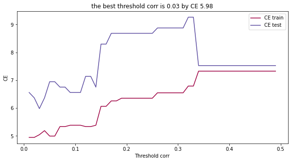

```python
df_selection_feature_by_corr.plot(x='threshold corr',y=['CE train','CE test'],kind='line',figsize=(10,5),title='CE by threshold corr',fontsize =10,colormap= sns.color_palette("Spectral", as_cmap=True))
plt.ylabel('CE')
plt.xlabel('Threshold corr')
plt.title('the best threshold corr is {:.2f} by CE {:.2f}'.format(float(best_corr['threshold corr']),float(best_corr['CE test'])))
plt.show()
```

## Selectiong features - in two ways!

We can also use Scikit-learn RFECV to use CV and choose the best number of features on this dataset. The default CV is 5-fold cross-validation. We will enter the Scikit-learn RepeatedKFold to repeat each KFold a few times with different splits.

```python
# find best subset of features on this dataset

from sklearn.feature_selection import RFECV
from sklearn.model_selection import RepeatedKFold

X_encoded = pd.DataFrame(StandardScaler().fit_transform(train),columns=train.columns)

selector = RFECV(SGDClassifier(random_state=1), cv=RepeatedKFold(n_splits=30, n_repeats=30, random_state=1)).fit(X_encoded, y_Survived )
selected_features = X_encoded.loc[:, selector.support_]
display(selected_features.head())

fig = go.Figure()
fig.add_trace(go.Scatter(x=[i for i in range(1, len(selector.grid_scores_) + 1)], y=selector.grid_scores_))
fig.update_xaxes(title_text="Number of features selected")
fig.update_yaxes(title_text="Cross validation score (nb of correct classifications)")
fig.show()
```

|  | Pclass | Sex | Age | SibSp | Parch | Fare | Name_Don | Name_Jonkheer | Name_Lady | Name_Master | Name_Miss | Name_Mme | Name_Mr | Name_Mrs | Name_Rev | Name_Sir | Embarked_S | B | D | E | F | T |
| --- | --- | --- | --- | --- | --- | --- | --- | --- | --- | --- | --- | --- | --- | --- | --- | --- | --- | --- | --- | --- | --- | --- |
| 0 | 0.827377 | 0.737695 | -0.540276 | 0.432793 | -0.473674 | -0.498948 | -0.03352 | -0.03352 | -0.03352 | -0.216803 | -0.506655 | -0.03352 | 0.850532 | -0.403962 | -0.082339 | -0.03352 | 0.615838 | -0.246403 | -0.208148 | -0.21395 | 1.003373 | -0.03352 |
| 1 | -1.566107 | -1.355574 | 0.630980 | 0.432793 | -0.473674 | 0.789405 | -0.03352 | -0.03352 | -0.03352 | -0.216803 | -0.506655 | -0.03352 | -1.175735 | 2.475480 | -0.082339 | -0.03352 | -1.623803 | -0.246403 | -0.208148 | -0.21395 | -0.996639 | -0.03352 |
| 2 | 0.827377 | -1.355574 | -0.247462 | -0.474545 | -0.473674 | -0.498948 | -0.03352 | -0.03352 | -0.03352 | -0.216803 | 1.973729 | -0.03352 | -1.175735 | -0.403962 | -0.082339 | -0.03352 | 0.615838 | -0.246403 | -0.208148 | -0.21395 | 1.003373 | -0.03352 |
| 3 | -1.566107 | -1.355574 | 0.411369 | 0.432793 | -0.473674 | 0.427056 | -0.03352 | -0.03352 | -0.03352 | -0.216803 | -0.506655 | -0.03352 | -1.175735 | 2.475480 | -0.082339 | -0.03352 | 0.615838 | -0.246403 | -0.208148 | -0.21395 | -0.996639 | -0.03352 |
| 4 | 0.827377 | 0.737695 | 0.411369 | -0.474545 | -0.473674 | -0.478817 | -0.03352 | -0.03352 | -0.03352 | -0.216803 | -0.506655 | -0.03352 | 0.850532 | -0.403962 | -0.082339 | -0.03352 | 0.615838 | -0.246403 | -0.208148 | -0.21395 | 1.003373 | -0.03352 |

[interactive chart not shown]

### Second way, faster to calculate

```python
selector.cv
```

```
RepeatedKFold(n_repeats=30, n_splits=30, random_state=1)
```

```python
from sklearn.feature_selection import SelectKBest
from sklearn.feature_selection import f_regression

all_features = pd.DataFrame(train,columns=train.columns)

fs = SelectKBest(k=20)
X_selected = fs.fit_transform(all_features, y_Survived)
sec_way = pd.DataFrame((train.loc[:, fs.get_support()]))
fs.scores_
```

```
array([1.15031272e+02, 3.72405724e+02, 3.91848139e+00, 1.11057220e+00,
       5.96346384e+00, 6.31228185e+01, 6.22686721e-01, 1.14121637e-01,
       6.22686721e-01, 5.95649127e-02, 6.22686721e-01, 1.60635682e+00,
       1.14121637e-01, 6.50363454e+00, 1.06509051e+02, 3.22216280e+00,
       1.60635682e+00, 3.83945495e+02, 1.15461086e+02, 1.60635682e+00,
       3.77052291e+00, 1.60635682e+00, 1.60635682e+00, 2.58959870e+01,
       1.18463440e-02, 2.03744599e+01, 1.97967932e-01, 3.08168420e+01,
       1.28524118e+01, 1.68725118e+01, 1.96313194e+01, 9.84968089e+01,
       1.16316444e-01, 6.22686721e-01])
```

# SELECT MODEL

We will try to find by GridSearchCV the best parameter to K for KNN

```python
from sklearn.neighbors import KNeighborsClassifier
from sklearn.model_selection import GridSearchCV


hyper_parameters = {'n_neighbors': list(range(1, 20))}

gs_neigh_model = GridSearchCV(KNeighborsClassifier(n_neighbors=5), hyper_parameters).fit(selected_features, y_Survived)
print('Accuracy score for classification:')
print('gs_neigh_model', gs_neigh_model.best_score_)
print('best params', gs_neigh_model.best_params_)
```

```
Accuracy score for classification:
gs_neigh_model 0.8316427091833531
best params {'n_neighbors': 8}
```

```python
sec_way.head(3)
```

|  | Pclass | Sex | Age | Parch | Fare | Name_Master | Name_Miss | Name_Mlle | Name_Mr | Name_Mrs | Name_Rev | Name_Sir | Name_the Countess | Embarked_C | Embarked_S | B | C | D | E | F |
| --- | --- | --- | --- | --- | --- | --- | --- | --- | --- | --- | --- | --- | --- | --- | --- | --- | --- | --- | --- | --- |
| 0 | 0.827377 | 0.737695 | -0.540276 | -0.473674 | -0.498948 | -0.216803 | -0.506655 | -0.047431 | 0.850532 | -0.403962 | -0.082339 | -0.03352 | -0.03352 | -0.482043 | 0.615838 | -0.246403 | -0.657629 | -0.208148 | -0.21395 | 1.003373 |
| 1 | -1.566107 | -1.355574 | 0.630980 | -0.473674 | 0.789405 | -0.216803 | -0.506655 | -0.047431 | -1.175735 | 2.475480 | -0.082339 | -0.03352 | -0.03352 | 2.074505 | -1.623803 | -0.246403 | 1.520614 | -0.208148 | -0.21395 | -0.996639 |
| 2 | 0.827377 | -1.355574 | -0.247462 | -0.473674 | -0.498948 | -0.216803 | 1.973729 | -0.047431 | -1.175735 | -0.403962 | -0.082339 | -0.03352 | -0.03352 | -0.482043 | 0.615838 | -0.246403 | -0.657629 | -0.208148 | -0.21395 | 1.003373 |

[output not shown]

|  | Classifier | Accuracy train | Accuracy test | CE train | CE test |
| --- | --- | --- | --- | --- | --- |
| 0 | KNeighborsClassifier | 0.861958 | 0.813433 | 4.767867 | 6.443891 |
| 1 | SVC | 0.857143 | 0.820896 | 4.934183 | 6.186136 |
| 2 | DecisionTreeClassifier | 0.967897 | 0.791045 | 1.108810 | 7.217135 |
| 3 | RandomForestClassifier | 0.967897 | 0.798507 | 1.108806 | 6.959386 |
| 4 | SGDClassifier | 0.815409 | 0.805970 | 6.375612 | 6.701634 |
| 5 | LogisticRegression | 0.842697 | 0.828358 | 5.433134 | 5.928375 |

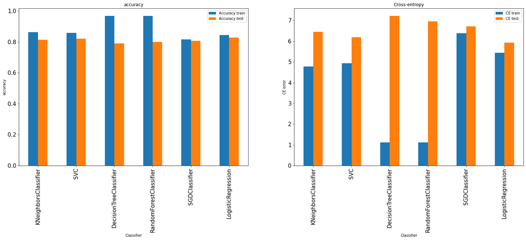

```python
classifiers = [
    KNeighborsClassifier(5),
    SVC(probability=True),
    DecisionTreeClassifier(criterion='entropy',max_features= 'auto'),
    RandomForestClassifier(),
    SGDClassifier(),
    LogisticRegression()]


df_Survived_statics = pd.DataFrame(columns=["Classifier", "Accuracy train","Accuracy test",'CE train','CE test'])

sss = StratifiedShuffleSplit(n_splits=10, test_size=0.1, random_state=0)


X_train, X_test, y_train, y_test = train_test_split(selected_features, y_Survived, test_size=0.3, random_state=42)

for clf in classifiers:
  name = clf.__class__.__name__
  clf.fit(X_train, y_train)
  train_predictions = clf.predict(X_test)
  acc_train = accuracy_score(clf.predict(X_train), y_train)
  acc_test = accuracy_score(y_test, train_predictions)
  ce_train = log_loss(clf.predict(X_train),y_train)
  ce_test = log_loss(clf.predict(X_test),y_test)

  df_Survived_statics = df_Survived_statics.append({"Classifier":name, "Accuracy train":acc_train,"Accuracy test":acc_test,'CE train':ce_train,'CE test':ce_test},ignore_index=True)

display(df_Survived_statics)
plt.figure(1)
plt.subplot(1,2,1)
plt.ylabel('accuracy')
plt.title('accuracy')
df_Survived_statics.plot(x='Classifier',y=["Accuracy train","Accuracy test"],kind='bar',figsize=(25,8),ax=plt.gca(),fontsize=15)
plt.subplot(1,2,2)
plt.ylabel('CE error')
plt.title('Cross-entropy')
df_Survived_statics.plot(x='Classifier',y=['CE train','CE test'],kind='bar',figsize=(25,8),ax=plt.gca(),fontsize=15)
plt.show()
```

## SELECT HIYPER-PARAMETERS

GridSearchCV with SVC

```
Accuracy score for classification:
gs_model 0.8305316678174629
best params {'C': 5.0, 'gamma': 'scale', 'kernel': 'rbf'}
```

```
<sklearn.metrics._plot.confusion_matrix.ConfusionMatrixDisplay at 0x7f25016dac18>
```

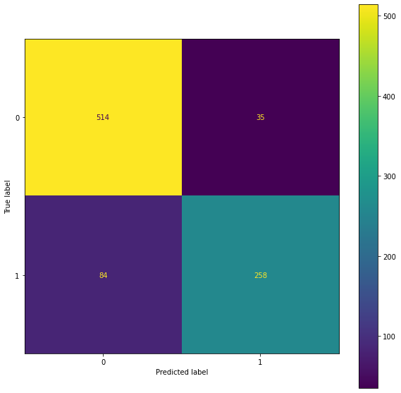

```python
# train with grid search and get best parameters
from sklearn.model_selection import GridSearchCV

# C=1.0, kernel='rbf', degree=3, gamma='scale', coef0=0.0
hyper_parameters = {'kernel': ('linear', 'poly', 'rbf', 'sigmoid'), 'C':[1.0, 3.0, 5.0, 8.0],'gamma': ['scale','auto']}

gs_model = GridSearchCV(SVC(random_state=1), hyper_parameters).fit(selected_features, y_Survived)
print('Accuracy score for classification:')
print('gs_model', gs_model.best_score_)
print('best params', gs_model.best_params_)

fig, ax = plt.subplots(figsize=(10, 10))

plot_confusion_matrix(gs_model,selected_features,y_Survived,ax=ax,values_format = '.5g')
```

RandomizedSearchCV with SVC

```
Accuracy score for classification:
rs_model 0.8305316678174629
best params {'kernel': 'rbf', 'gamma': 'auto', 'C': 5.0}
```

```
<sklearn.metrics._plot.confusion_matrix.ConfusionMatrixDisplay at 0x7f25014db6a0>
```

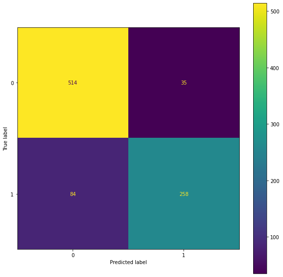

```python
# train with random search and get best parameters
from sklearn.model_selection import RandomizedSearchCV
from scipy.stats import uniform

np.random.seed(1)
distributions = {'kernel': ('linear', 'poly', 'rbf', 'sigmoid'), 'C':[1.0, 3.0, 5.0, 8.0],'gamma': ['scale','auto']}

rs_model = RandomizedSearchCV(SVC(random_state=1), distributions, random_state=1).fit(selected_features, y_Survived)
print('Accuracy score for classification:')
print('rs_model', rs_model.best_score_)
print('best params', rs_model.best_params_)

fig, ax = plt.subplots(figsize=(10, 10))

plot_confusion_matrix(rs_model,selected_features,y_Survived,ax=ax,values_format = '.5g')
```

with RandomizedSearchCV and LogisticRegression

```
Accuracy score for classification:
rs_model 0.8249199673592367
best params {'solver': 'newton-cg', 'penalty': 'l2', 'max_iter': 2350, 'C': 4}
```

```
<sklearn.metrics._plot.confusion_matrix.ConfusionMatrixDisplay at 0x7f25014db550>
```

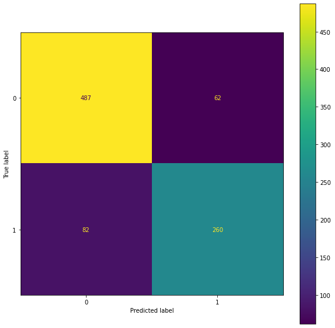

```python
# train with random search and get best parameters
from sklearn.model_selection import RandomizedSearchCV
from scipy.stats import uniform

np.random.seed(1)
distributions = dict(penalty=['l2', 'l1', 'elasticnet'], C=np.arange(1,10,3), solver=['lbfgs','newton-cg','liblinear', 'sag', 'saga'], max_iter=np.arange(50,5000,100))

rs_model = RandomizedSearchCV(LogisticRegression(random_state=1), distributions, random_state=1).fit(selected_features, y_Survived)
print('Accuracy score for classification:')
print('rs_model', rs_model.best_score_)
print('best params', rs_model.best_params_)

fig, ax = plt.subplots(figsize=(10, 10))

plot_confusion_matrix(rs_model,selected_features,y_Survived,ax=ax,values_format = '.5g')
```

# estimators

```python
X_train, X_test, y_train, y_test = train_test_split(train, y_Survived, test_size=0.2, random_state=1)
```

```python
# get score with nfold bagging
from sklearn.ensemble import BaggingClassifier

bag_fold_model = BaggingClassifier(SVC(kernel= 'rbf', gamma= 'auto', C= 5.0), random_state=1, bootstrap=False).fit(seselected_featuresc_way, y_Survived)
print('Accuracy score for classification:')
print('bag_fold_model', bag_fold_model.score(selected_features, y_Survived).mean())

results_bag_fold = bag_fold_model.predict(test[selected_features.columns])

fig, ax = plt.subplots(figsize=(10, 10))
plot_confusion_matrix(bag_fold_model,selected_features,y_Survived,ax=ax,values_format = '.5g')
```

[output not shown]

```python
# get score with bootstrap bagging
bag_boot_model = BaggingClassifier(base_estimator=SVC(), n_estimators=1000, random_state=1, bootstrap=False).fit(selected_features, y_Survived)
print('Accuracy score for classification:')
print('bag_boot_model', bag_fold_model.score(selected_features, y_Survived).mean())
results_abg_boot = bag_boot_model.predict(test[selected_features.columns])

fig, ax = plt.subplots(figsize=(10, 10))
plot_confusion_matrix(bag_boot_model,selected_features,y_Survived,ax=ax,values_format = '.5g')
plt.show()
```

[output not shown]

```python
# get score with ada boosting
from sklearn.ensemble import AdaBoostClassifier

ada_boost_model = AdaBoostClassifier( base_estimator=LogisticRegression(),random_state=1).fit(selected_features, y_Survived)
print('Accuracy score for classification:')
print('ada_boost_model', ada_boost_model.score(selected_features, y_Survived).mean())
results_ada = ada_boost_model.predict(test[selected_features.columns])

fig, ax = plt.subplots(figsize=(10, 10))
plot_confusion_matrix(ada_boost_model,selected_features,y_Survived,ax=ax,values_format = '.5g')
plt.show()
```

[output not shown]

### Create predictions and file for subbmission

```python
sub = pd.read_csv('gender_submission.csv')
submission = pd.DataFrame(index=sub.PassengerId,columns=['Survived'])
submission['Survived'] = results
submission.to_csv('paz.csv')
```

MY BEST RESULT: 0.79665 TOP 5.3%

[figure not shown]

The history of my subbmission:

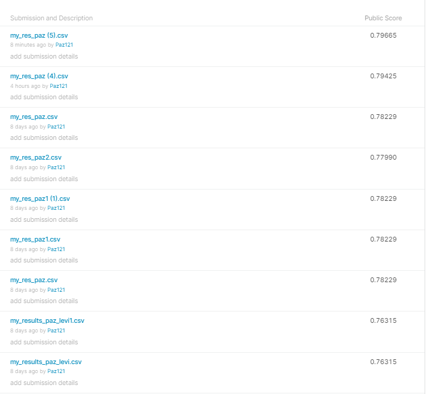

### **I tried in several ways, in a huge variety of models.**

### **I fronted the missing data with machine learning models! - This is not a common thing.**

### **This approach resulted in a very large project!**

### **There are two models of classification problem here - of cabin and of survivors.**

### **There are models here with predictions also for the regression problem for the purpose of filling the age column**

# **Summary:**

**There are things to improve like to explore in more depth the various hyper parameters of each of the models and measure the results :)**

# In conclusion

sources: https://stackoverflow.com/questions/1482308/how-to-get-all-subsets-of-a-set-powerset